# Desmatamento no Brasil: v2 (exploração)

Desmatamento por mandato, uso da terra, mineração, cenários até 2030, fogo, fiscalização do Ibama, alertas DETER, comparação por município e fogo dentro e fora de terras indígenas

Data de Publicação

26 de outubro de 2026

**Sobre esta versão**

Esta é a versão de exploração (v2) da prática de desmatamento. A versão publicada para os alunos, com as animações, continua em `aulas/r/desmatamento.qmd` (v1). Aqui os gráficos são estáticos e servem para escolher, com calma, o que vale a pena refinar e animar.

**Premissa de análise:** nos cenários e comparações, o governo de Jair Bolsonaro (2019–2022) é usado como **baliza** para o que se pode esperar de um eventual governo de Flávio Bolsonaro, considerando a convergência entre os dois discursos e as avaliações de ambientalistas, cientistas e movimentos sociais sobre o plano de governo. Essa é uma premissa explícita, não um dado: Flávio Bolsonaro não governou e, portanto, não tem histórico próprio nestes dados.

# 1. Desmatamento por mandato

Os mandatos têm durações diferentes, então comparamos a **taxa média anual** de cada um. Cada ano PRODES (agosto a julho) é atribuído a quem governou a maior parte dele. O valor de 1988, que é a média de 1977 a 1988, fica de fora.

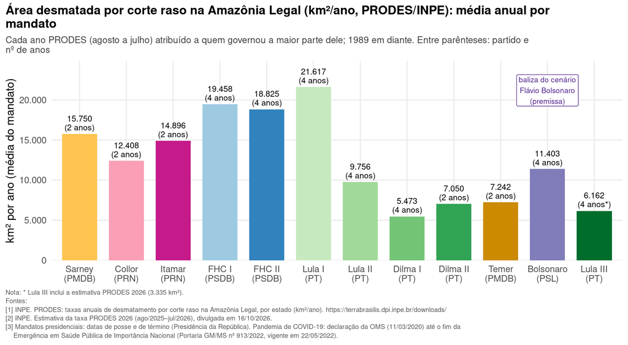

Média anual da área desmatada por corte raso na Amazônia Legal (PRODES) em cada mandato presidencial. Fontes: INPE. PRODES: taxas anuais de desmatamento por corte raso na Amazônia Legal, por estado (km²/ano). https://terrabrasilis.dpi.inpe.br/downloads/ INPE. Estimativa da taxa PRODES 2026 (ago/2025–jul/2026), divulgada em 16/10/2026. Mandatos presidenciais: datas de posse e de término (Presidência da República). Pandemia de COVID-19: declaração da OMS (11/03/2020) até o fim da Emergência em Saúde Pública de Importância Nacional (Portaria GM/MS nº 913/2022, vigente em 22/05/2022).

O PRODES mede só o corte raso na Amazônia Legal. O MapBiomas permite olhar **todos os biomas**. Aqui usamos a **conversão bruta** de vegetação nativa em usos humanos (pastagem, agricultura, mineração, área urbana), calculada a partir das transições ano a ano, que é uma medida mais próxima de “desmatamento” do que a simples variação da área de vegetação.

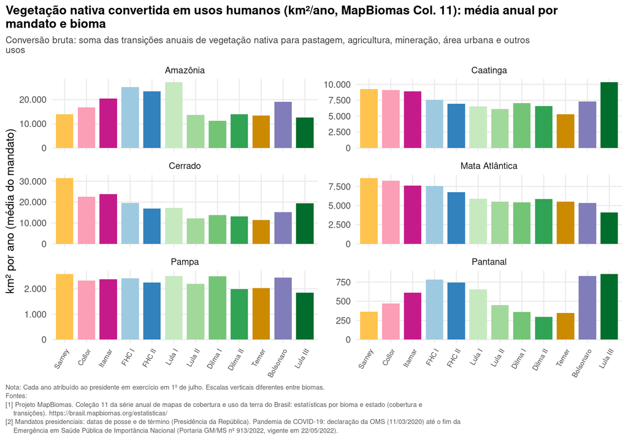

Conversão bruta de vegetação nativa em usos humanos, por bioma, em cada mandato. Fontes: Projeto MapBiomas. Coleção 11 da série anual de mapas de cobertura e uso da terra do Brasil: estatísticas por bioma e estado (cobertura e transições). https://brasil.mapbiomas.org/estatisticas/ Mandatos presidenciais: datas de posse e de término (Presidência da República). Pandemia de COVID-19: declaração da OMS (11/03/2020) até o fim da Emergência em Saúde Pública de Importância Nacional (Portaria GM/MS nº 913/2022, vigente em 22/05/2022).

# 2. O que substitui a vegetação nativa

Para onde vai a área desmatada? Abaixo do zero está o movimento contrário: áreas de uso humano que voltaram a ser vegetação nativa (**regeneração**).

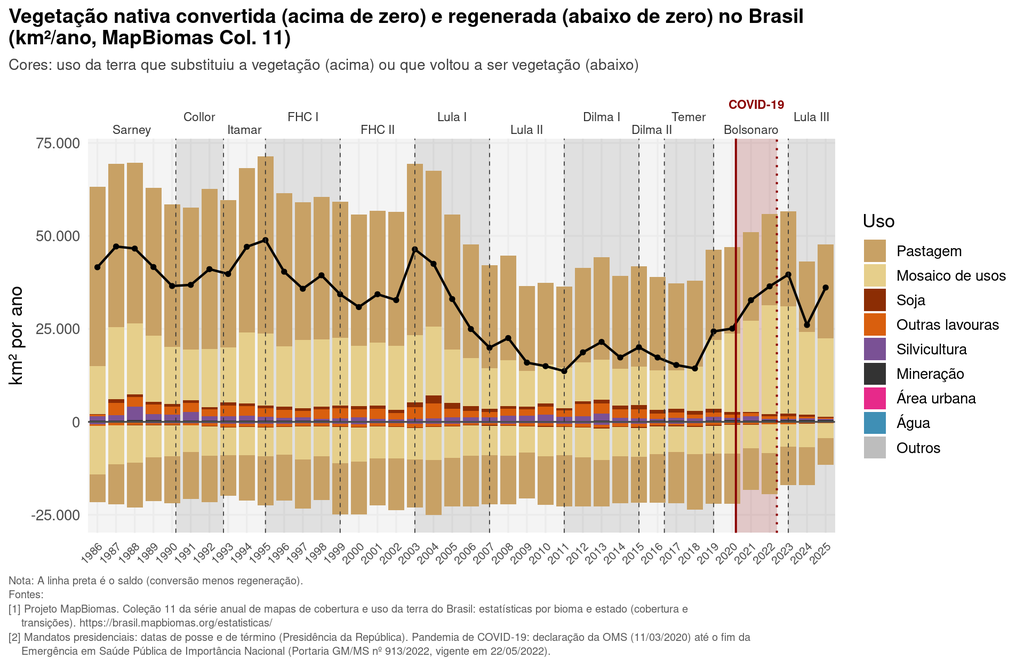

Conversão e regeneração anuais de vegetação nativa no Brasil, por uso da terra. Fontes: Projeto MapBiomas. Coleção 11 da série anual de mapas de cobertura e uso da terra do Brasil: estatísticas por bioma e estado (cobertura e transições). https://brasil.mapbiomas.org/estatisticas/ Mandatos presidenciais: datas de posse e de término (Presidência da República). Pandemia de COVID-19: declaração da OMS (11/03/2020) até o fim da Emergência em Saúde Pública de Importância Nacional (Portaria GM/MS nº 913/2022, vigente em 22/05/2022).

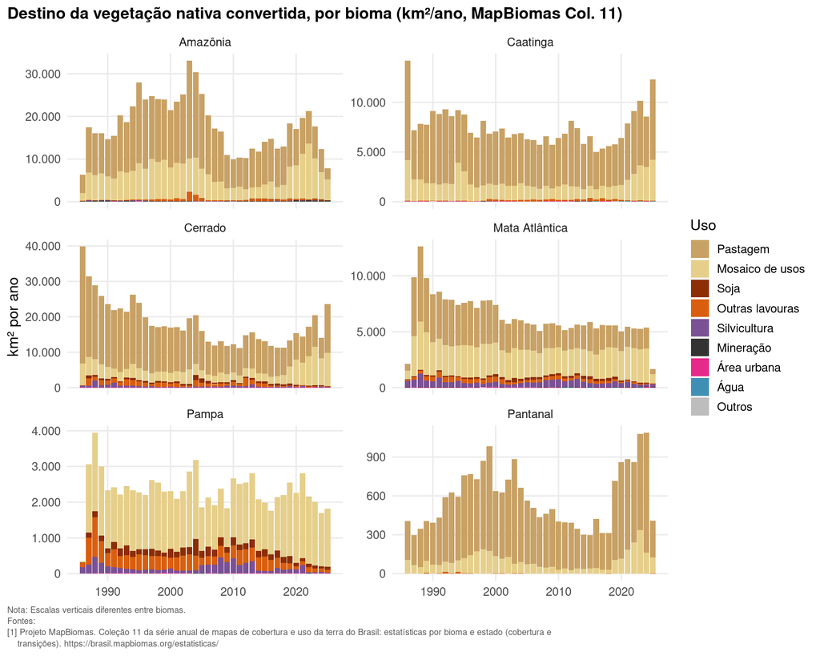

Uso da terra que substituiu a vegetação nativa convertida, por bioma e ano. Fontes: Projeto MapBiomas. Coleção 11 da série anual de mapas de cobertura e uso da terra do Brasil: estatísticas por bioma e estado (cobertura e transições). https://brasil.mapbiomas.org/estatisticas/

# 3. Mineração e garimpo

O MapBiomas mapeia a área de mineração, que inclui tanto a mineração industrial quanto o garimpo. Separar os dois exige a coleção específica de mineração do MapBiomas (próximo passo).

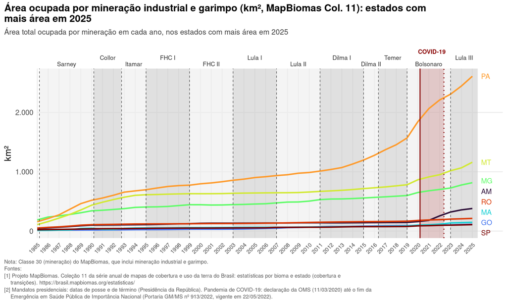

Área de mineração por estado ao longo do tempo. Fontes: Projeto MapBiomas. Coleção 11 da série anual de mapas de cobertura e uso da terra do Brasil: estatísticas por bioma e estado (cobertura e transições). https://brasil.mapbiomas.org/estatisticas/ Mandatos presidenciais: datas de posse e de término (Presidência da República). Pandemia de COVID-19: declaração da OMS (11/03/2020) até o fim da Emergência em Saúde Pública de Importância Nacional (Portaria GM/MS nº 913/2022, vigente em 22/05/2022).

# 4. Pastagem e soja

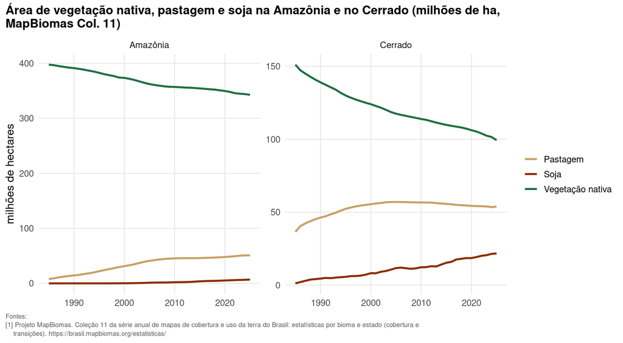

Evolução das áreas de vegetação nativa, pastagem e soja nos biomas Amazônia e Cerrado. Fontes: Projeto MapBiomas. Coleção 11 da série anual de mapas de cobertura e uso da terra do Brasil: estatísticas por bioma e estado (cobertura e transições). https://brasil.mapbiomas.org/estatisticas/

# 5. As duas fontes concordam?

Antes de cruzar dados, vale testar se as fontes contam a mesma história. Cada ponto é um estado em um ano: no eixo horizontal, o desmatamento do PRODES; no vertical, a conversão de **vegetação florestal** do bioma Amazônia segundo o MapBiomas.

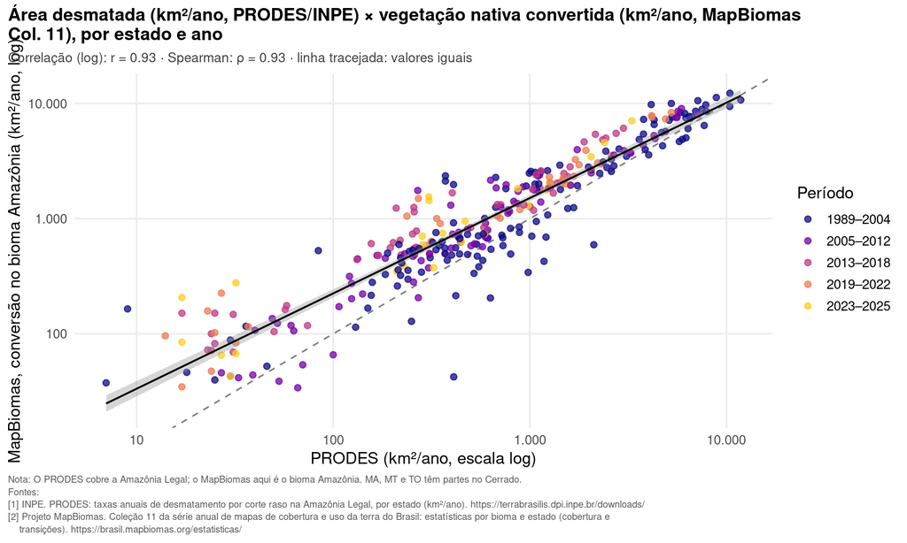

Concordância entre as duas fontes de desmatamento, por estado e ano. Fontes: INPE. PRODES: taxas anuais de desmatamento por corte raso na Amazônia Legal, por estado (km²/ano). https://terrabrasilis.dpi.inpe.br/downloads/ Projeto MapBiomas. Coleção 11 da série anual de mapas de cobertura e uso da terra do Brasil: estatísticas por bioma e estado (cobertura e transições). https://brasil.mapbiomas.org/estatisticas/

# 6. Cenários até 2030

Projeção da taxa PRODES para o próximo mandato (2027–2030), partindo da estimativa de 2026. São **cenários**, não previsões: cada um depende de uma premissa explícita.

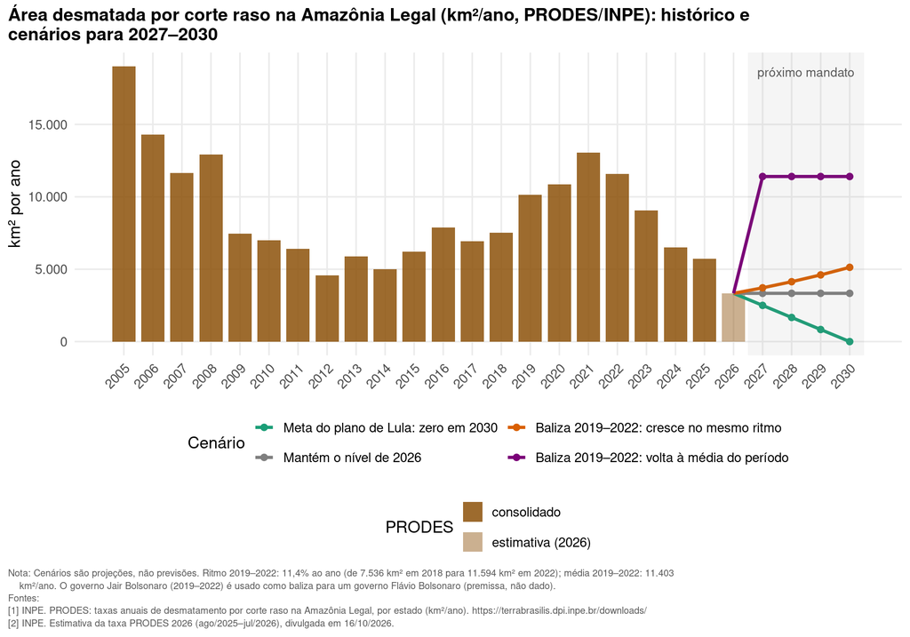

Taxa anual de desmatamento observada e quatro cenários para o próximo mandato. Fontes: INPE. PRODES: taxas anuais de desmatamento por corte raso na Amazônia Legal, por estado (km²/ano). https://terrabrasilis.dpi.inpe.br/downloads/ INPE. Estimativa da taxa PRODES 2026 (ago/2025–jul/2026), divulgada em 16/10/2026.

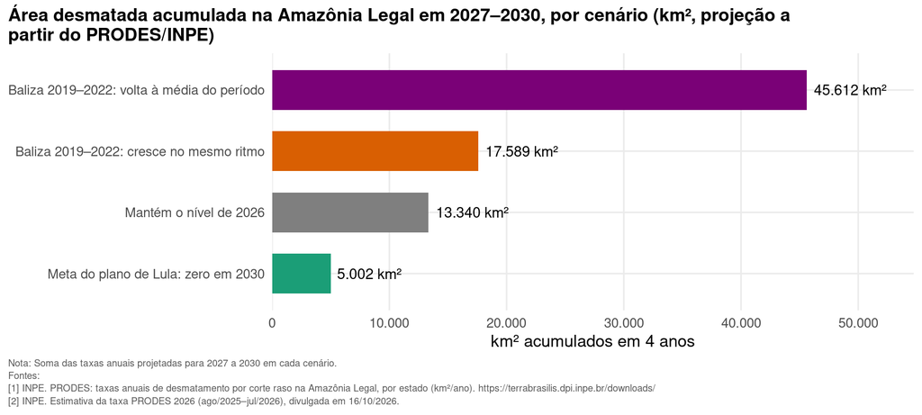

Área total desmatada em quatro anos em cada cenário. Fontes: INPE. PRODES: taxas anuais de desmatamento por corte raso na Amazônia Legal, por estado (km²/ano). https://terrabrasilis.dpi.inpe.br/downloads/ INPE. Estimativa da taxa PRODES 2026 (ago/2025–jul/2026), divulgada em 16/10/2026.

# 7. Fogo

O INPE conta **focos de calor** detectados por satélite. Para comparar anos diferentes, usamos só o **satélite de referência** (o mesmo sensor ao longo da série, desde 2003). Focos não são área queimada: um incêndio grande gera muitos focos, e um pequeno pode não ser visto. A série serve para comparar tendências.

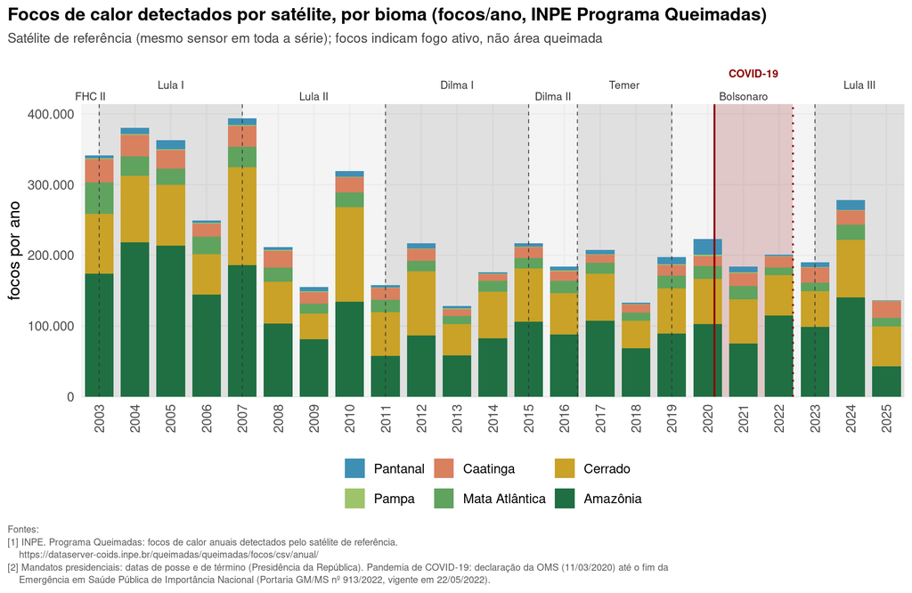

Número anual de focos de calor por bioma. Fontes: INPE. Programa Queimadas: focos de calor anuais detectados pelo satélite de referência. https://dataserver-coids.inpe.br/queimadas/queimadas/focos/csv/anual/ Mandatos presidenciais: datas de posse e de término (Presidência da República). Pandemia de COVID-19: declaração da OMS (11/03/2020) até o fim da Emergência em Saúde Pública de Importância Nacional (Portaria GM/MS nº 913/2022, vigente em 22/05/2022).

[figure not shown]

Média anual de focos de calor em cada mandato, por bioma. Fontes: INPE. Programa Queimadas: focos de calor anuais detectados pelo satélite de referência. https://dataserver-coids.inpe.br/queimadas/queimadas/focos/csv/anual/ Mandatos presidenciais: datas de posse e de término (Presidência da República). Pandemia de COVID-19: declaração da OMS (11/03/2020) até o fim da Emergência em Saúde Pública de Importância Nacional (Portaria GM/MS nº 913/2022, vigente em 22/05/2022).

O fogo depende muito do clima: anos de seca forte (como os de El Niño, 2015–2016 e 2023–2024) concentram focos mesmo sem mudança de política. Por isso, comparar mandatos pela média de focos mistura política e clima, e o cruzamento com dados de chuva fica para uma próxima etapa.

# 8. Fiscalização

Os autos de infração do Ibama mostram a **atividade de fiscalização**: quantas infrações foram autuadas e o valor das multas aplicadas. Para o desmatamento, o tipo mais relevante é **Flora** (corte, queima e comércio ilegal de madeira e vegetação). Os valores estão em **US$ de 2025** (reais corrigidos pelo IPCA e convertidos pelo dólar médio de 2025), a partir de 1995, primeiro ano inteiro do real. A série começa em **1998**: antes disso, quase não há autos de flora nos dados abertos (provavelmente registros antigos não digitalizados), e até 2004 boa parte dos autos não traz valor de multa. Multa aplicada não é multa paga: grande parte é contestada ou nunca cobrada.

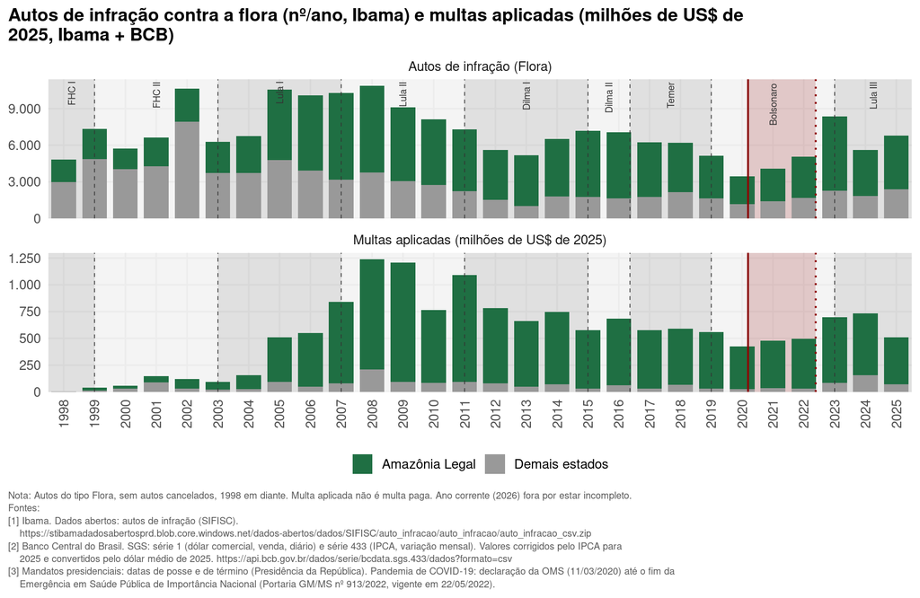

Número de autos de infração contra a flora e valor das multas aplicadas pelo Ibama. Fontes: Ibama. Dados abertos: autos de infração (SIFISC). https://stibamadadosabertosprd.blob.core.windows.net/dados-abertos/dados/SIFISC/auto_infracao/auto_infracao/auto_infracao_csv.zip Banco Central do Brasil. SGS: série 1 (dólar comercial, venda, diário) e série 433 (IPCA, variação mensal). Valores corrigidos pelo IPCA para 2025 e convertidos pelo dólar médio de 2025. https://api.bcb.gov.br/dados/serie/bcdata.sgs.433/dados?formato=csv Mandatos presidenciais: datas de posse e de término (Presidência da República). Pandemia de COVID-19: declaração da OMS (11/03/2020) até o fim da Emergência em Saúde Pública de Importância Nacional (Portaria GM/MS nº 913/2022, vigente em 22/05/2022).

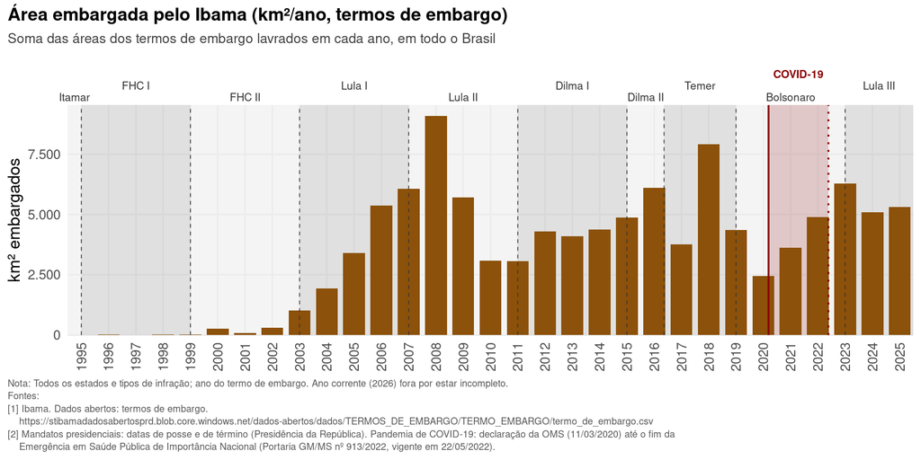

Área total embargada pelo Ibama em cada ano. Fontes: Ibama. Dados abertos: termos de embargo. https://stibamadadosabertosprd.blob.core.windows.net/dados-abertos/dados/TERMOS_DE_EMBARGO/TERMO_EMBARGO/termo_de_embargo.csv Mandatos presidenciais: datas de posse e de término (Presidência da República). Pandemia de COVID-19: declaração da OMS (11/03/2020) até o fim da Emergência em Saúde Pública de Importância Nacional (Portaria GM/MS nº 913/2022, vigente em 22/05/2022).

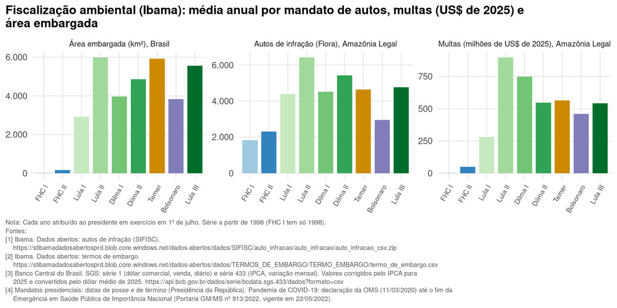

Indicadores de fiscalização do Ibama, média anual por mandato. Fontes: Ibama. Dados abertos: autos de infração (SIFISC). https://stibamadadosabertosprd.blob.core.windows.net/dados-abertos/dados/SIFISC/auto_infracao/auto_infracao/auto_infracao_csv.zip Ibama. Dados abertos: termos de embargo. https://stibamadadosabertosprd.blob.core.windows.net/dados-abertos/dados/TERMOS_DE_EMBARGO/TERMO_EMBARGO/termo_de_embargo.csv Banco Central do Brasil. SGS: série 1 (dólar comercial, venda, diário) e série 433 (IPCA, variação mensal). Valores corrigidos pelo IPCA para 2025 e convertidos pelo dólar médio de 2025. https://api.bcb.gov.br/dados/serie/bcdata.sgs.433/dados?formato=csv Mandatos presidenciais: datas de posse e de término (Presidência da República). Pandemia de COVID-19: declaração da OMS (11/03/2020) até o fim da Emergência em Saúde Pública de Importância Nacional (Portaria GM/MS nº 913/2022, vigente em 22/05/2022).

# 9. Fiscalização e desmatamento

Fiscalizar mais reduz o desmatamento? A relação é de mão dupla: **mais desmatamento gera mais autos** (há mais infrações para autuar), e **mais fiscalização deveria gerar menos desmatamento** depois. Para separar um pouco os dois efeitos, comparamos os autos de cada ano com o desmatamento dos anos **anteriores**, do **mesmo ano** e dos anos **seguintes**, estado por estado, usando a correlação de postos (Spearman) dentro de cada estado.

Fazemos isso de dois jeitos. Com os **valores anuais**, a correlação mistura a relação entre as duas séries com as tendências de longo prazo de cada uma (as duas caíram em boa parte do período, por motivos que podem ser diferentes). Com as **variações de um ano para o outro**, a tendência sai da conta e sobra a pergunta: quando os autos sobem num estado, o desmatamento cai depois?

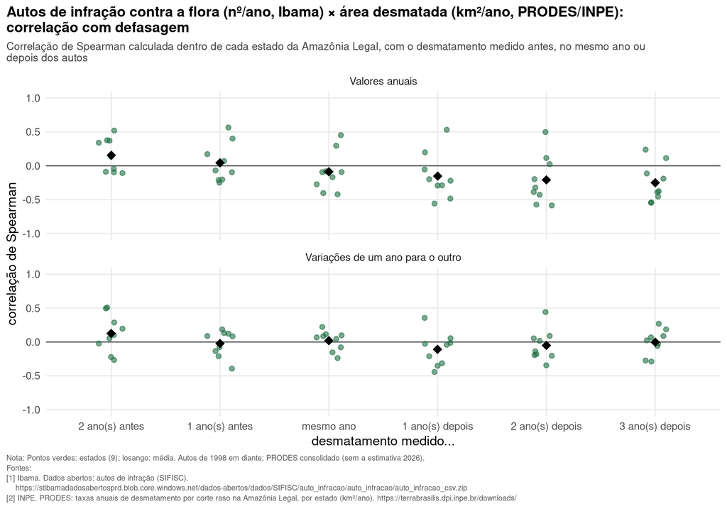

Correlação entre autos de infração e desmatamento em diferentes defasagens, por estado. Fontes: Ibama. Dados abertos: autos de infração (SIFISC). https://stibamadadosabertosprd.blob.core.windows.net/dados-abertos/dados/SIFISC/auto_infracao/auto_infracao/auto_infracao_csv.zip INPE. PRODES: taxas anuais de desmatamento por corte raso na Amazônia Legal, por estado (km²/ano). https://terrabrasilis.dpi.inpe.br/downloads/

| medida | defasagem (anos) | média entre estados | menor | maior |
| --- | --- | --- | --- | --- |
| Valores anuais | -2 | 0.16 | -0.11 | 0.52 |
| Valores anuais | -1 | 0.04 | -0.25 | 0.56 |
| Valores anuais | 0 | -0.09 | -0.42 | 0.45 |
| Valores anuais | 1 | -0.15 | -0.56 | 0.53 |
| Valores anuais | 2 | -0.21 | -0.59 | 0.50 |
| Valores anuais | 3 | -0.25 | -0.55 | 0.24 |
| Variações de um ano para o outro | -2 | 0.13 | -0.27 | 0.51 |
| Variações de um ano para o outro | -1 | -0.02 | -0.39 | 0.19 |
| Variações de um ano para o outro | 0 | 0.02 | -0.24 | 0.22 |
| Variações de um ano para o outro | 1 | -0.11 | -0.44 | 0.36 |
| Variações de um ano para o outro | 2 | -0.05 | -0.34 | 0.44 |
| Variações de um ano para o outro | 3 | 0.00 | -0.29 | 0.27 |

**O que os números mostram (e o que não mostram):**

- Com os **valores anuais**, a média entre estados fica levemente negativa e se torna mais negativa quanto mais à frente olhamos (mais autos num ano, menos desmatamento três anos depois). Mas esse padrão pode vir só das tendências: os autos subiram até 2008 e o desmatamento caiu de 2005 a 2012, então qualquer série que suba e depois caia “parece” antecipar a queda.
- Com as **variações anuais**, as correlações ficam próximas de zero em todas as defasagens, e os estados discordam muito entre si. Ou seja, nesta escala (estado e ano) **não aparece um sinal claro** de que um aumento de autos seja seguido de queda do desmatamento.
- Isso **não** quer dizer que a fiscalização não funciona. Contar autos é uma medida grosseira (um auto pode ser de 1 hectare ou de 10 mil), e o efeito da fiscalização passa também por embargos, apreensões, crédito rural bloqueado e pela simples expectativa de ser pego. Estudos que usam desenhos mais cuidadosos, como os do Climate Policy Initiative (PUC-Rio) sobre o DETER e a fiscalização em municípios da Amazônia, encontram efeitos dissuasórios relevantes. Esta correlação simples é só um ponto de partida para a análise por município, com área embargada e alertas do DETER.

# 10. Alertas do DETER

O **DETER** é o sistema de alertas do INPE: imagens de resolução mais baixa, analisadas quase em tempo real, para orientar a fiscalização. O **PRODES** é o mapeamento anual, mais detalhado, que dá a taxa oficial. Os dois usam o mesmo “ano PRODES” (agosto a julho). Aqui, o desmatamento do DETER soma as classes de corte raso, corte raso com vegetação e mineração; degradação, corte seletivo e cicatrizes de queimada são mostrados à parte.

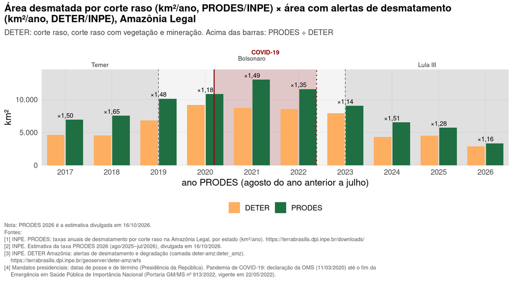

Comparação anual entre a taxa PRODES e a área de alertas de desmatamento do DETER. Fontes: INPE. PRODES: taxas anuais de desmatamento por corte raso na Amazônia Legal, por estado (km²/ano). https://terrabrasilis.dpi.inpe.br/downloads/ INPE. Estimativa da taxa PRODES 2026 (ago/2025–jul/2026), divulgada em 16/10/2026. INPE. DETER Amazônia: alertas de desmatamento e degradação (camada deter-amz:deter_amz). https://terrabrasilis.dpi.inpe.br/geoserver/deter-amz/wfs Mandatos presidenciais: datas de posse e de término (Presidência da República). Pandemia de COVID-19: declaração da OMS (11/03/2020) até o fim da Emergência em Saúde Pública de Importância Nacional (Portaria GM/MS nº 913/2022, vigente em 22/05/2022).

O DETER enxerga menos que o PRODES (polígonos pequenos e áreas sob nuvem escapam), mas acompanha bem a **direção** da taxa. A razão PRODES ÷ DETER varia de ano a ano, por isso o DETER serve para antecipar a tendência, não o número exato.

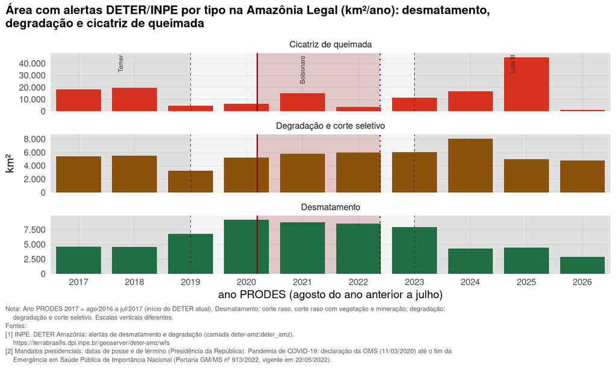

Área anual com alertas DETER, separada em desmatamento, degradação e cicatrizes de queimada. Fontes: INPE. DETER Amazônia: alertas de desmatamento e degradação (camada deter-amz:deter_amz). https://terrabrasilis.dpi.inpe.br/geoserver/deter-amz/wfs Mandatos presidenciais: datas de posse e de término (Presidência da República). Pandemia de COVID-19: declaração da OMS (11/03/2020) até o fim da Emergência em Saúde Pública de Importância Nacional (Portaria GM/MS nº 913/2022, vigente em 22/05/2022).

O desmatamento caiu a partir de 2023, mas **degradação e fogo não acompanharam**: o ano PRODES 2025 (agosto de 2024 a julho de 2025), que inclui a temporada de seca extrema de 2024, tem a maior área de cicatrizes de queimada da série. Floresta degradada pelo fogo não entra na taxa de desmatamento do PRODES, mas perde carbono e biodiversidade e fica mais vulnerável a ser desmatada depois. Esse é um dos pontos que ambientalistas e cientistas destacam ao avaliar os números recentes.

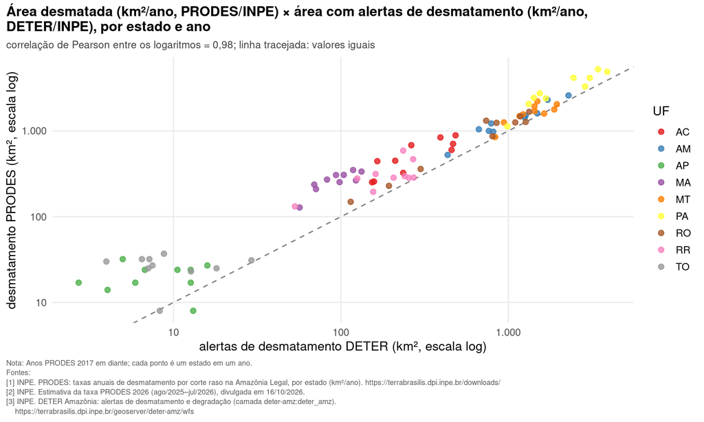

Relação entre DETER e PRODES para cada estado e ano, cor por estado. Fontes: INPE. PRODES: taxas anuais de desmatamento por corte raso na Amazônia Legal, por estado (km²/ano). https://terrabrasilis.dpi.inpe.br/downloads/ INPE. Estimativa da taxa PRODES 2026 (ago/2025–jul/2026), divulgada em 16/10/2026. INPE. DETER Amazônia: alertas de desmatamento e degradação (camada deter-amz:deter_amz). https://terrabrasilis.dpi.inpe.br/geoserver/deter-amz/wfs

A mesma relação, agora com a **forma** indicando o estado e a **cor** indicando o ano, para ver se a relação muda ao longo do tempo. O teste é a correlação de Pearson entre os logaritmos das duas áreas.

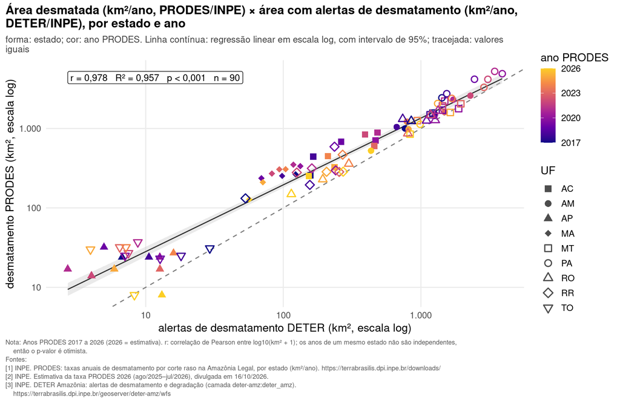

Relação entre DETER e PRODES para cada estado e ano, forma por estado e cor por ano. Fontes: INPE. PRODES: taxas anuais de desmatamento por corte raso na Amazônia Legal, por estado (km²/ano). https://terrabrasilis.dpi.inpe.br/downloads/ INPE. Estimativa da taxa PRODES 2026 (ago/2025–jul/2026), divulgada em 16/10/2026. INPE. DETER Amazônia: alertas de desmatamento e degradação (camada deter-amz:deter_amz). https://terrabrasilis.dpi.inpe.br/geoserver/deter-amz/wfs

# 11. DETER e PRODES por município

Por estado, os alertas do DETER acompanham de perto o PRODES. Por município dá para ver o padrão com mais detalhe e achar os lugares que **destoam**: onde o DETER registra bem menos (ou bem mais) do que o PRODES mapeia depois. O PRODES por município é a soma dos polígonos anuais de desmatamento que caem em cada município; ela fica entre 83% e 106% da taxa oficial de cada ano (a taxa inclui uma correção para áreas sob nuvem).

Para reduzir o ruído de anos com valores pequenos, somamos 2017 a 2025 em cada município e usamos só os municípios com pelo menos 5 km² desmatados no período.

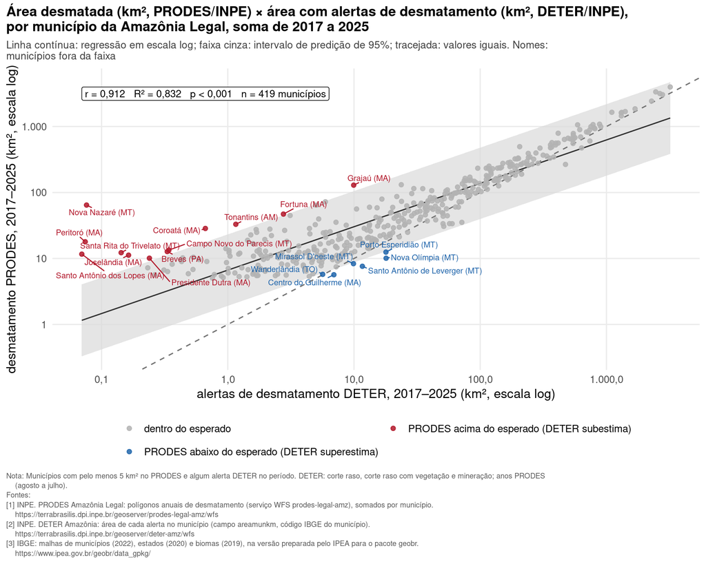

Área desmatada (PRODES) e área de alertas (DETER) somadas de 2017 a 2025 em cada município da Amazônia Legal; destacados os que ficam fora do intervalo de predição de 95%. Fontes: INPE. PRODES Amazônia Legal: polígonos anuais de desmatamento (serviço WFS prodes-legal-amz), somados por município. https://terrabrasilis.dpi.inpe.br/geoserver/prodes-legal-amz/wfs INPE. DETER Amazônia: área de cada alerta no município (campo areamunkm, código IBGE do município). https://terrabrasilis.dpi.inpe.br/geoserver/deter-amz/wfs IBGE: malhas de municípios (2022), estados (2020) e biomas (2019), na versão preparada pelo IPEA para o pacote geobr. https://www.ipea.gov.br/geobr/data_gpkg/

| município | UF | PRODES (km²) | DETER (km²) | PRODES ÷ DETER | PRODES esperado (km²) | situação |
| --- | --- | --- | --- | --- | --- | --- |
| Nova Nazaré | MT | 64,50 | 0,1 | 849,07 | 1,20 | PRODES acima do esperado |
| Peritoró | MA | 17,90 | 0,1 | 241,57 | 1,20 | PRODES acima do esperado |
| Santo Antônio dos Lopes | MA | 11,60 | 0,1 | 166,98 | 1,20 | PRODES acima do esperado |
| Santa Rita do Trivelato | MT | 12,20 | 0,1 | 85,68 | 1,90 | PRODES acima do esperado |
| Coroatá | MA | 28,50 | 0,7 | 42,94 | 5,10 | PRODES acima do esperado |
| Joselândia | MA | 11,20 | 0,2 | 68,67 | 2,00 | PRODES acima do esperado |
| Tonantins | AM | 33,00 | 1,2 | 28,52 | 7,30 | PRODES acima do esperado |
| Nova Olímpia | MT | 10,10 | 18,0 | 0,56 | 44,50 | PRODES abaixo do esperado |
| Santo Antônio de Leverger | MT | 7,60 | 11,6 | 0,65 | 33,50 | PRODES abaixo do esperado |
| Grajaú | MA | 129,20 | 9,9 | 13,00 | 30,20 | PRODES acima do esperado |
| Centro do Guilherme | MA | 5,70 | 6,9 | 0,82 | 23,80 | PRODES abaixo do esperado |
| Campo Novo do Parecis | MT | 13,40 | 0,3 | 39,26 | 3,30 | PRODES acima do esperado |
| Breves | PA | 12,70 | 0,3 | 38,38 | 3,20 | PRODES acima do esperado |
| Presidente Dutra | MA | 10,10 | 0,2 | 42,23 | 2,60 | PRODES acima do esperado |
| Fortuna | MA | 47,10 | 2,8 | 17,07 | 13,00 | PRODES acima do esperado |
| Wanderlândia | TO | 5,80 | 5,6 | 1,02 | 20,80 | PRODES abaixo do esperado |
| Mirassol D’oeste | MT | 8,40 | 9,9 | 0,84 | 30,10 | PRODES abaixo do esperado |
| Porto Esperidião | MT | 12,50 | 17,9 | 0,70 | 44,40 | PRODES abaixo do esperado |

Municípios com **PRODES bem acima do esperado** pelo DETER são lugares onde o desmatamento escapou dos alertas: polígonos pequenos (abaixo da área mínima do DETER), cobertura de nuvens persistente na época dos alertas ou desmatamento gradual. O contrário (**DETER acima do esperado**) costuma indicar alertas que o PRODES não confirmou como corte raso, por exemplo áreas de degradação intensa ou de mineração. A lista serve como ponto de partida para olhar caso a caso, não como diagnóstico.

# 12. Terras indígenas e fogo

**Comparar o número de TIs com o número de focos por estado** mede principalmente o **tamanho** de cada estado: estados grandes têm mais TIs e mais focos. A pergunta que interessa é outra: **dentro das TIs há mais ou menos fogo do que fora delas, na mesma área?** Para isso, cada foco foi localizado dentro ou fora de uma TI pelas coordenadas, e calculamos a **densidade** de focos (focos por 1.000 km² por ano).

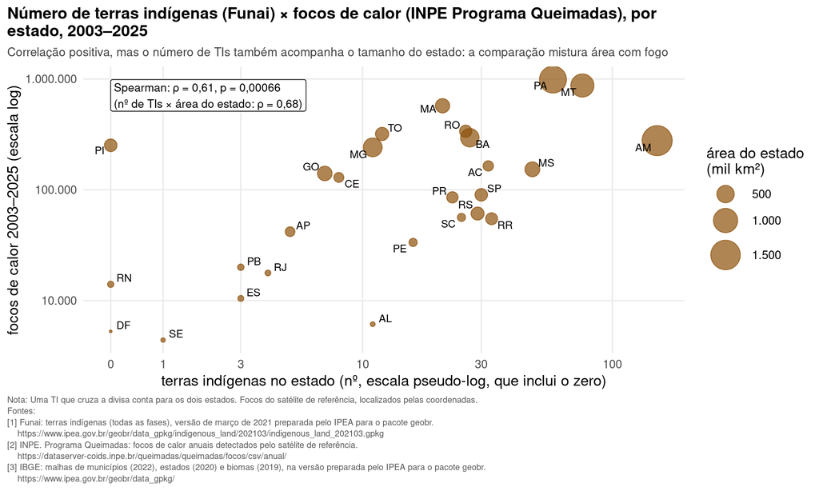

Número de terras indígenas e número total de focos de calor por estado (2003 a 2025). Fontes: Funai: terras indígenas (todas as fases), versão de março de 2021 preparada pelo IPEA para o pacote geobr. https://www.ipea.gov.br/geobr/data_gpkg/indigenous_land/202103/indigenous_land_202103.gpkg INPE. Programa Queimadas: focos de calor anuais detectados pelo satélite de referência. https://dataserver-coids.inpe.br/queimadas/queimadas/focos/csv/anual/ IBGE: malhas de municípios (2022), estados (2020) e biomas (2019), na versão preparada pelo IPEA para o pacote geobr. https://www.ipea.gov.br/geobr/data_gpkg/

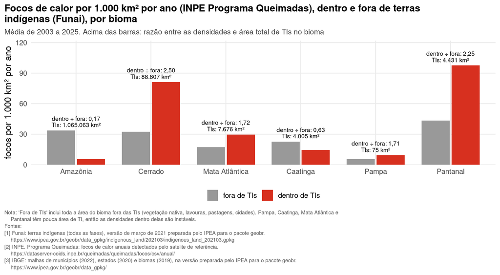

Densidade média anual de focos de calor dentro e fora de terras indígenas, por bioma (2003 a 2025). Fontes: Funai: terras indígenas (todas as fases), versão de março de 2021 preparada pelo IPEA para o pacote geobr. https://www.ipea.gov.br/geobr/data_gpkg/indigenous_land/202103/indigenous_land_202103.gpkg INPE. Programa Queimadas: focos de calor anuais detectados pelo satélite de referência. https://dataserver-coids.inpe.br/queimadas/queimadas/focos/csv/anual/ IBGE: malhas de municípios (2022), estados (2020) e biomas (2019), na versão preparada pelo IPEA para o pacote geobr. https://www.ipea.gov.br/geobr/data_gpkg/

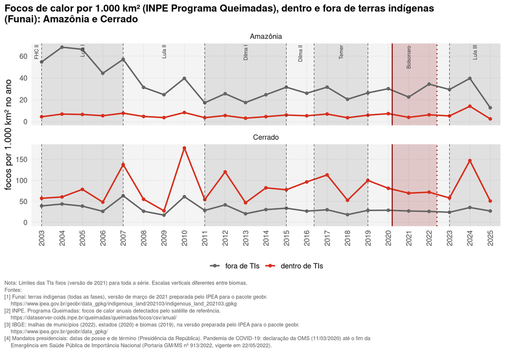

Densidade anual de focos de calor dentro e fora de terras indígenas na Amazônia e no Cerrado. Fontes: Funai: terras indígenas (todas as fases), versão de março de 2021 preparada pelo IPEA para o pacote geobr. https://www.ipea.gov.br/geobr/data_gpkg/indigenous_land/202103/indigenous_land_202103.gpkg INPE. Programa Queimadas: focos de calor anuais detectados pelo satélite de referência. https://dataserver-coids.inpe.br/queimadas/queimadas/focos/csv/anual/ IBGE: malhas de municípios (2022), estados (2020) e biomas (2019), na versão preparada pelo IPEA para o pacote geobr. https://www.ipea.gov.br/geobr/data_gpkg/ Mandatos presidenciais: datas de posse e de término (Presidência da República). Pandemia de COVID-19: declaração da OMS (11/03/2020) até o fim da Emergência em Saúde Pública de Importância Nacional (Portaria GM/MS nº 913/2022, vigente em 22/05/2022).

# 13. Próximos dados

Para os temas que queremos cruzar, estas são as fontes candidatas. Cada uma entra no painel (`dados/painel_longo.csv`) com as mesmas chaves: estado, bioma, ano, variável, valor, unidade e fonte.

| Tema | Fonte candidata | O que permite mostrar |
| --- | --- | --- |
| Queimadas (área queimada) | MapBiomas Fogo; INPE (área queimada) | fogo x desmatamento x seca, por mandato (focos: já na seção 7) |
| Orçamento e pessoal | Portal da Transparência; SIOP; Painel Estatístico de Pessoal | recursos e efetivo de MMA, Ibama, ICMBio, Funai |
| Forças de segurança e crime | Polícia Federal; Fórum Brasileiro de Segurança Pública | operações, apreensões, crimes ambientais |
| Garimpo e terras indígenas | MapBiomas Mineração e Terras Indígenas; Funai | garimpo e desmatamento dentro e fora de terras indígenas (fogo: seção 12) |
| Valor da terra | preços de terra por região (consultorias e institutos de economia agrícola) | valorização da terra desmatada |
| Produção e renda | IBGE (PAM, PPM, PEVS, Censo Agropecuário) | renda por hectare de pastagem, soja, extrativismo |
| Fundos e investimentos | Fundo Amazônia (BNDES); Fundo Clima; ODA ambiental | recursos para preservação ao longo do tempo |
| Serviços ecossistêmicos e carbono | literatura científica de valoração; mercados de carbono | valor da floresta em pé x convertida |